# PEC2 ADO

Sara Álvarez González

Mayo de 2020

## 0. Extraer datos

Cargamos los datos que nos dan:

```r
counts = read.csv("counts.csv",header=T,sep = ";")
target = read.csv("targets.csv",header=T,sep = ",")
```

Primero extraer las que son del mismo grupo a variables separadas para después seleccionar 10 de cada uno de los grupos:

```r
NIT <- subset(target,grepl("^(NIT)", target$Group))
SFI <- subset(target,grepl("^(SFI)", target$Group))
ELI <- subset(target,grepl("^(ELI)", target$Group))

set.seed(12)

NIT_10 <- sample_n(NIT, 10)
SFI_10 <- sample_n(SFI, 10)
ELI_10 <- sample_n(ELI, 10)


columnas <- rbind(NIT_10,SFI_10,ELI_10)
grupos <- as.factor(columnas$Group)
colNIT_SFI <- rbind(NIT_10,SFI_10)
g1 <- factor(colNIT_SFI$Group)
colSFI_ELI <- rbind(SFI_10,ELI_10)
g2 <- factor(colSFI_ELI$Group)
colNIT_ELI <- rbind(NIT_10,ELI_10)
g3 <- factor(colNIT_ELI$Group)
```

Finalmente extraer con las variables anteriores los datos con los que se va a trabajar:

```r
nit <- counts[,NIT_10$Sample_Name]
sfi <- counts[,SFI_10$Sample_Name]
eli <- counts[,ELI_10$Sample_Name]

datos <- cbind(nit,sfi,eli)
rownames(datos) <- counts[,1]

#write.csv(datos,"datos.csv", row.names = FALSE)
```

## 1. Filtrado

En primer lugar haremos un pequeño análisis de calidad:

- Miraremos si en nuestro datos se encuentra algún NA:

```r
table(is.na(datos))
```

```
##
##   FALSE
## 1686060
```

- Para simplicar el análisis y evitar tratar con datos de expresión que no aporten y solo puedan perjudicar al estudio, se eliminarán las muestras de expresión con media igual a 0.

```r
med_gen<-apply(datos, 1, mean)
table(med_gen == 0)
```

```
##
## FALSE  TRUE
## 45968 10234
```

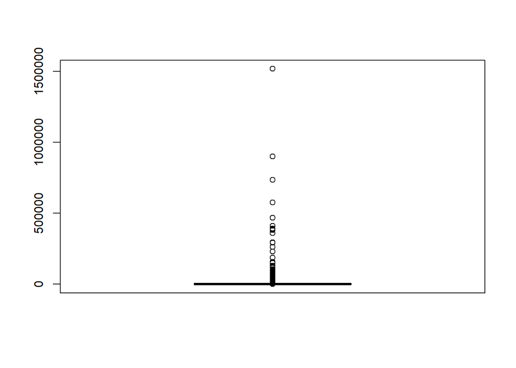

```r
boxplot(med_gen)
```

```r
borrar<-datos[which(med_gen ==0),]
i<-intersect(rownames(borrar), rownames(datos))
datos<-datos[!rownames(datos)%in% i,]
```

Así pues han sido eliminados **10234**, reduciendo a **45968** datos de expresión.

Podemos ver a través de un gráfico de barras la expresión que van a presentar los loci de nuestros datos, observando que aunque en general va a ser baja, en algunos es bastante destcable:

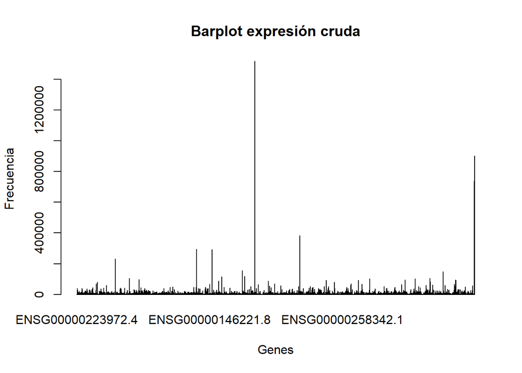

```r
media_genes_elim<-apply(datos, 1, mean)
barplot(media_genes_elim,main = 'Barplot expresión cruda', xlim=NULL, xlab = 'Genes', ylab='Frecuencia')
```

## 2. Normalización

Ahora que hemos simplificado un poco los datos, llevaremos a cabo un normalizado **TMM**, no es necesario definirlo con la función *normalizeCounts*, ya que por defecto es la que hace:

```r
datos_f <- normalizeCounts(datos)
```

```
## Using edgeR-TMM normalization.
```

```
## Calculating normalization factors with the TMM method.
```

```
## Estimating common dispersion.
```

```
## Estimating tagwise dispersions.
```

```
## Calculating effective library sizes.
```

```
## Adjusting counts to effective library sizes using tagwise dispersions.
```

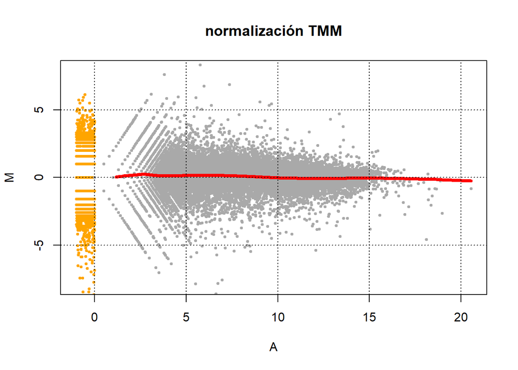

```r
maPlot(datos_f[,1], datos_f[,2],
       pch=19, cex=.5, ylim=c(-8,8),
       allCol="darkgrey", lowess=TRUE)
grid(col="black")
title("normalización TMM")
```

Podemos observar el efecto de la normalización mirando las expresiones medias de cada gen, comparando los datos en crudo y los datos normalizados:

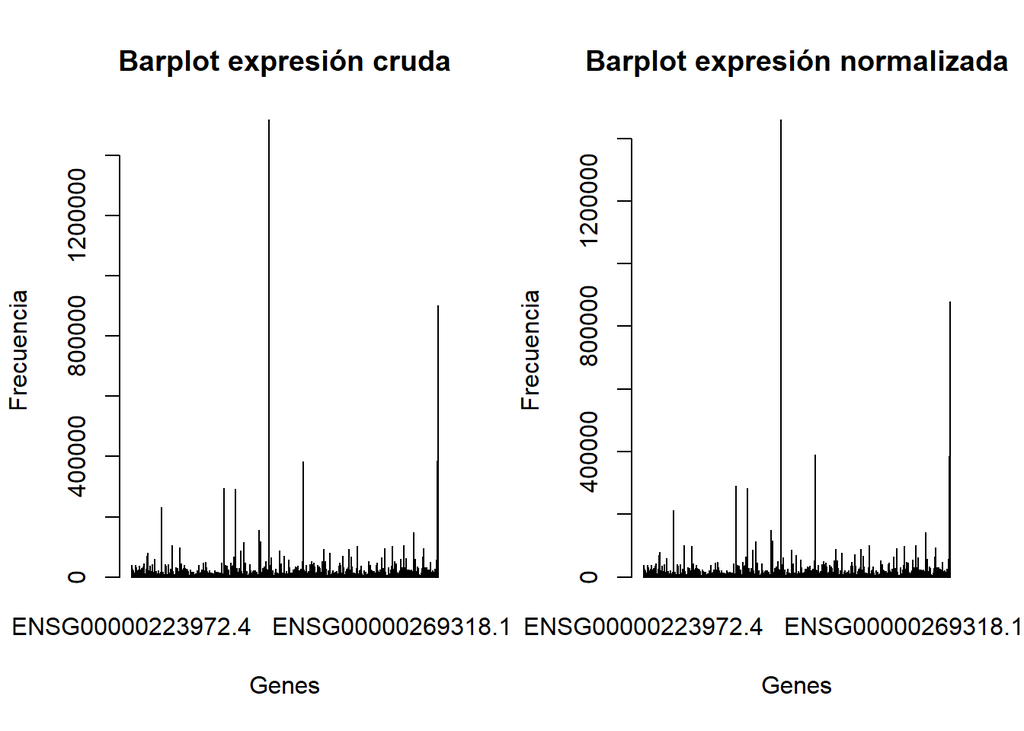

```r
par(mfrow=c(1,2))

media_genes_elim<-apply(datos, 1, mean)
barplot(media_genes_elim,main = 'Barplot expresión cruda', xlim=NULL, xlab = 'Genes', ylab='Frecuencia')

media_genes_nor<-apply(datos_f, 1, mean)
barplot(media_genes_nor,main = 'Barplot expresión normalizada', xlim=NULL, xlab = 'Genes', ylab='Frecuencia')
```

## 2. Identificación de genes diferencialmente expresados (DE)

Para hacer este paso, existen principalmente tres paquetes para hacerlo con características diferentes: *edgeR*, *DESeq* y *tweeDEseq*. En nuestro caso se ha decidido proceder con **edgeR**.

Separamos los grupos para las comparaciones parciales:

```r
primer <- cbind(datos[,1:10],datos[,11:20])
segun <- cbind(datos[,11:20],datos[,21:30])
terc <- cbind(datos[,1:10],datos[,21:30])
```

Primero haremos la comparación de los sujetos de **NIT** y **SFI**:

```r
# Se aplica un refiltrado
d <- DGEList(counts = primer, group = g1)
d <- calcNormFactors(d)
m <- sweep(d$counts, 2, 1e6 / d$samples$lib.size, '*')
ridx_primer <- rowSums(m>1) >= 2
table(ridx_primer)
```

```
## ridx_primer
## FALSE  TRUE
## 27297 18671
```

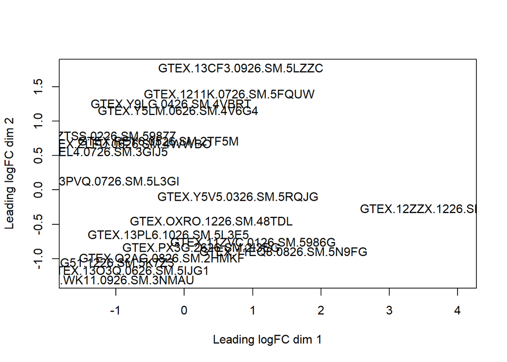

```r
d <- d[ridx_primer,]
plotMDS(d)
```

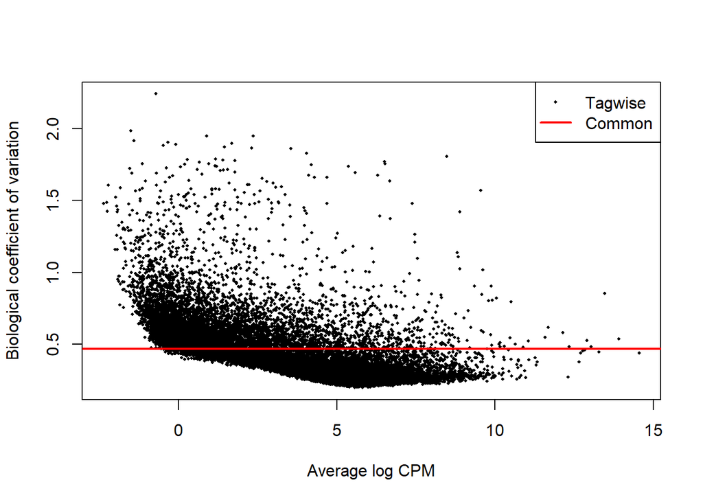

```r
d1 <- estimateCommonDisp(d)
dtag1 <- estimateTagwiseDisp(d1)
res.common1  <- exactTest(d1, pair=c("NIT", "SFI"), dispersion="common")
res.tagwise1 <- exactTest(dtag1, pair=c("NIT", "SFI"), dispersion="tagwise")

plotBCV(dtag1, cex=0.4)
```

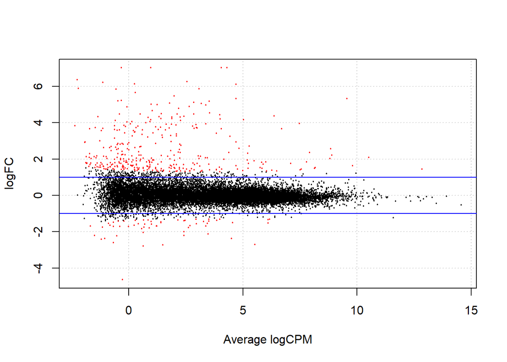

```r
dec1 <- decideTestsDGE(res.common1,p=0.001, adjust="BH")
dtag_primer <- rownames(d1)[as.logical(dec1)]
plotSmear(res.common1, de.tags = dtag_primer)
abline(h=c(-1,1),col="blue")
```

```r
# así se calculan los genes up/down regulados:
d1_df <- as.data.frame(dec1)
d1_df[,2] <- rownames(res.common1)
up1 <- d1_df[which(d1_df$`SFI-NIT`==1),]
down1 <- d1_df[which(d1_df$`SFI-NIT`==-1),]
summary(dec1)
```

```
##        SFI-NIT
## Down        57
## NotSig   18277
## Up         337
```

```r
genes_1 <- c(up1$V2,down1$V2)
```

A continuación la comparación de los sujetos de **SFI** y **ELI**:

```r
# Se aplica un refiltrado
d <- DGEList(counts = segun, group = g2)
d <- calcNormFactors(d)
m <- sweep(d$counts, 2, 1e6 / d$samples$lib.size, '*')
ridx_segun <- rowSums(m>1) >= 2
table(ridx_segun)
```

```
## ridx_segun
## FALSE  TRUE
## 27265 18703
```

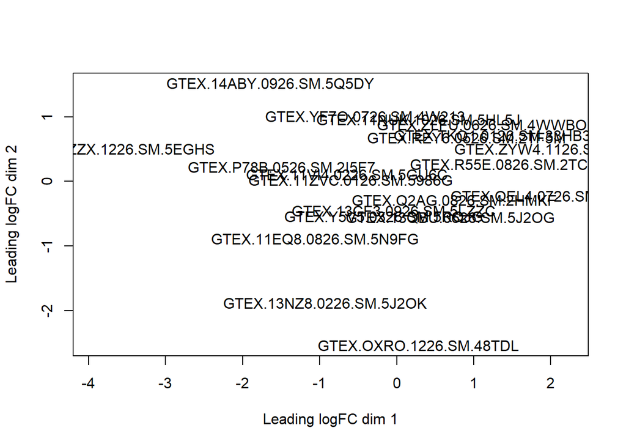

```r
d <- d[ridx_segun,]
plotMDS(d)
```

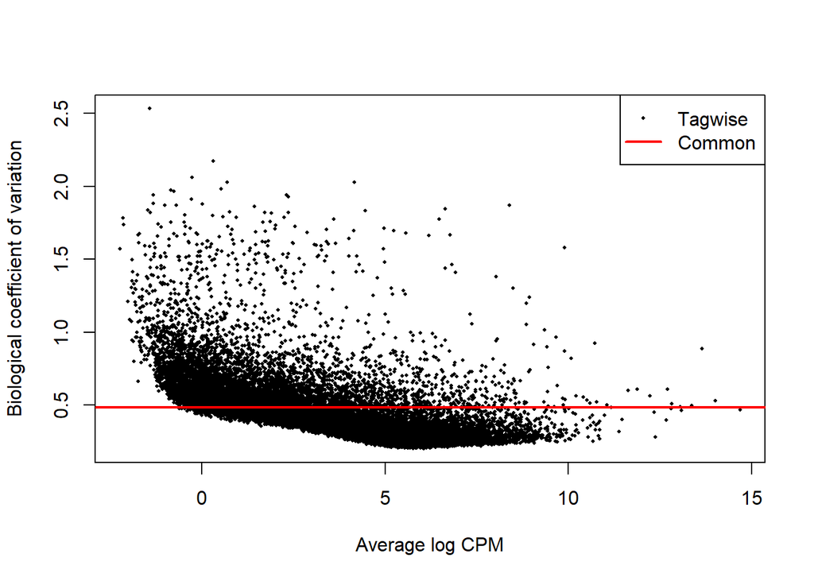

```r
d2 <- estimateCommonDisp(d)
dtag2 <- estimateTagwiseDisp(d2)
res.common2  <- exactTest(d2, pair=c("SFI", "ELI"), dispersion="common")
res.tagwise2 <- exactTest(dtag2, pair=c("SFI", "ELI"), dispersion="tagwise")

plotBCV(dtag2, cex=0.4)
```

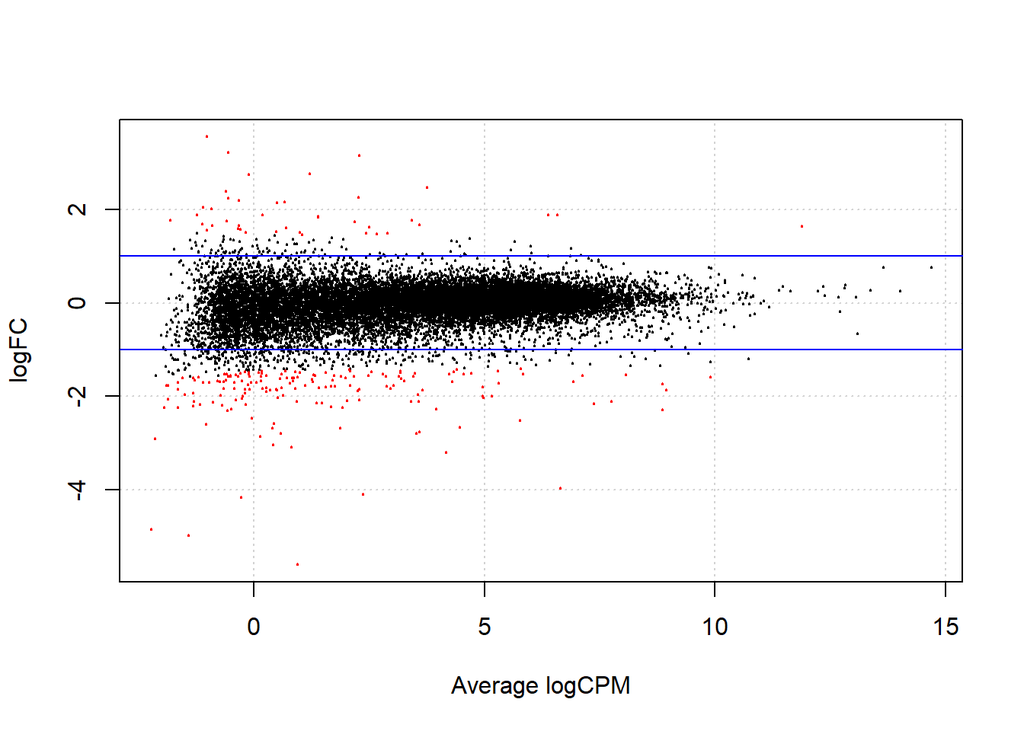

```r
dec2 <- decideTestsDGE(res.common2,p=0.001, adjust="BH")
dtag_segun <- rownames(d2)[as.logical(dec2)]
plotSmear(res.common2, de.tags = dtag_segun)
abline(h=c(-1,1),col="blue")
```

```r
# así se calculan los genes up/down regulados:
d2_df <- as.data.frame(dec2)
d2_df[,2] <- rownames(res.common2)
up2 <- d2_df[which(d2_df$`ELI-SFI`==1),]
down2 <- d2_df[which(d2_df$`ELI-SFI`==-1),]
summary(dec2)
```

```
##        ELI-SFI
## Down       170
## NotSig   18492
## Up          41
```

```r
genes_2 <- c(up2$V2,down2$V2)
```

Finalmente, la comparación de los sujetos de **NIT** y **ELI**:

```r
# Se aplica un refiltrado
d <- DGEList(counts = terc, group = g3)
d <- calcNormFactors(d)
m <- sweep(d$counts, 2, 1e6 / d$samples$lib.size, '*')
ridx_terc <- rowSums(m>1) >= 2
table(ridx_terc)
```

```
## ridx_terc
## FALSE  TRUE
## 27679 18289
```

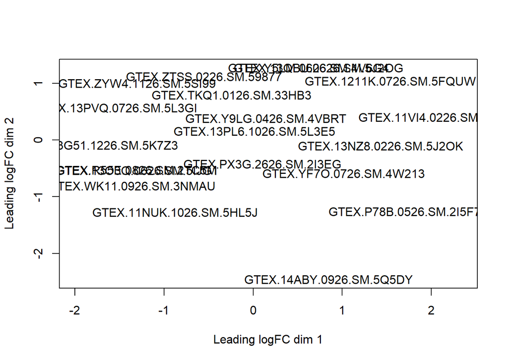

```r
d <- d[ridx_terc,]
plotMDS(d)
```

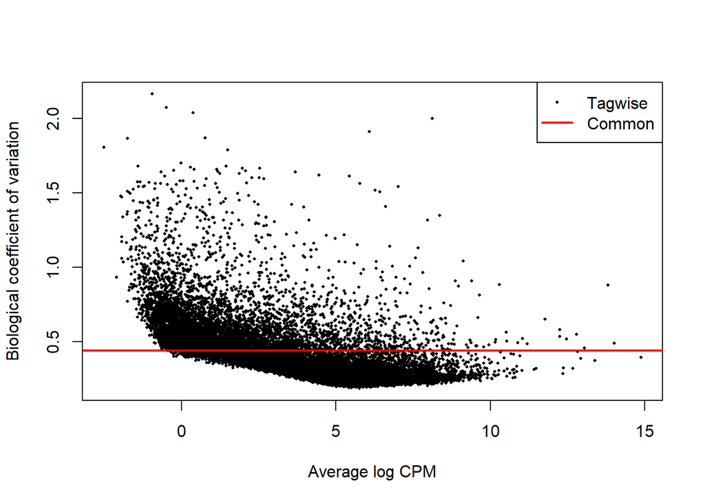

```r
d3 <- estimateCommonDisp(d)
dtag3 <- estimateTagwiseDisp(d3)
res.common3  <- exactTest(d3, pair=c("NIT", "ELI"), dispersion="common")
res.tagwise3 <- exactTest(dtag3, pair=c("NIT", "ELI"), dispersion="tagwise")

plotBCV(dtag3, cex=0.4)
```

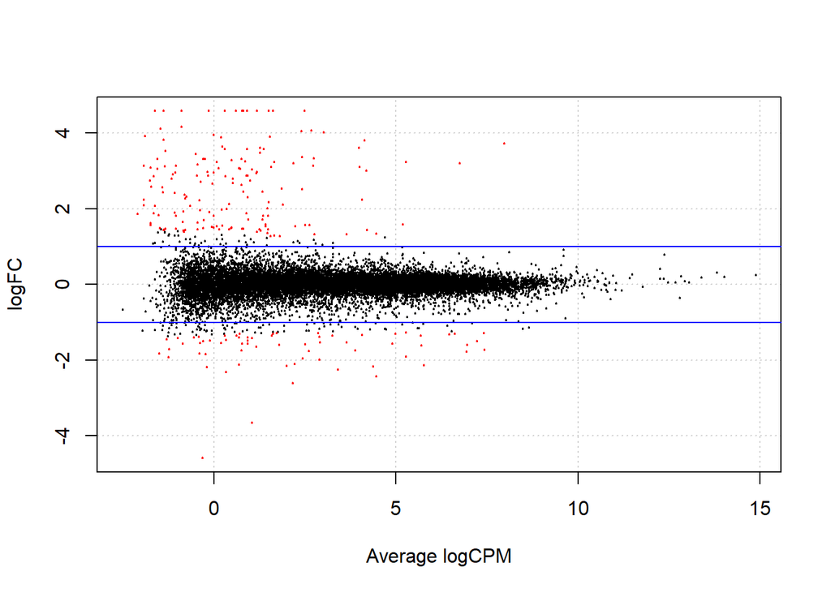

```r
dec3 <- decideTestsDGE(res.common3,p=0.001, adjust="BH")
dtag_terc <- rownames(d3)[as.logical(dec3)]
plotSmear(res.common3, de.tags = dtag_terc)
abline(h=c(-1,1),col="blue")
```

```r
# así se calculan los genes up/down regulados:
d3_df <- as.data.frame(dec3)
d3_df[,2] <- rownames(res.common3)
up3 <- d3_df[which(d3_df$`ELI-NIT`==1),]
down3 <- d3_df[which(d3_df$`ELI-NIT`==-1),]
summary(dec3)
```

```
##        ELI-NIT
## Down        66
## NotSig   18061
## Up         162
```

```r
genes_3 <- c(up3$V2,down3$V2)
```

En este *diagrama de Venn* podemos observar los genes que fueron DE en las tres comparaciones, y cuáles de ellos coinciden entre una comparación y otra.

```r
library(VennDiagram)
```

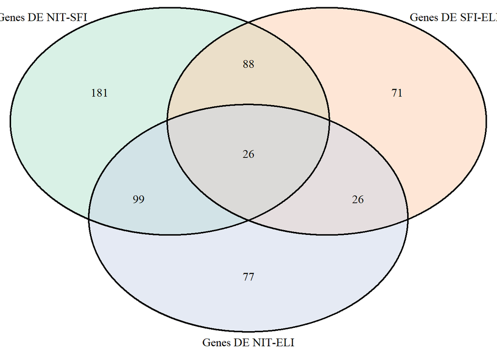

```r
library(RColorBrewer)
vd <- venn.diagram(x = list("Genes DE NIT-SFI" = genes_1, "Genes DE SFI-ELI" = genes_2,"Genes DE NIT-ELI" = genes_3), fill = brewer.pal(3, "Pastel2"), filename = NULL)
grid.draw(vd)
```

Tendremos por tanto un intersecto de los genes DE de las tres comparaciones con los **26** genes DE que hemos visto en el gráfico anterior:

```r
comunes <- intersect(intersect(genes_1,genes_2),genes_3)
comunes
```

```
##  [1] "ENSG00000211593.2" "ENSG00000239855.1" "ENSG00000241351.1"
##  [4] "ENSG00000243290.1" "ENSG00000240864.1" "ENSG00000242076.1"
##  [7] "ENSG00000169245.4" "ENSG00000253755.1" "ENSG00000211896.2"
## [10] "ENSG00000211934.2" "ENSG00000211936.2" "ENSG00000211937.2"
## [13] "ENSG00000211959.2" "ENSG00000211637.2" "ENSG00000211640.3"
## [16] "ENSG00000211644.2" "ENSG00000211648.2" "ENSG00000211653.2"
## [19] "ENSG00000211660.3" "ENSG00000211662.2" "ENSG00000211666.2"
## [22] "ENSG00000211670.2" "ENSG00000211673.2" "ENSG00000211677.2"
## [25] "ENSG00000151365.2" "ENSG00000108342.8"
```

```r
length(comunes)
```

```
## [1] 26
```

```r
up<-intersect(intersect(up1$V2,up2$V2),up3$V2)
length(up)
```

```
## [1] 1
```

```r
down<-intersect(intersect(down1$V2,down2$V2),down3$V2)
length(down)
```

```
## [1] 1
```

## 3.Anotación de los resultados

```r
library(biomaRt)
mart <- useMart(biomart = "ensembl", dataset = "hsapiens_gene_ensembl")

genes_comunes<-getBM(attributes =  c("hgnc_symbol"), filters = "ensembl_gene_id_version", values =comunes, mart = mart)
```

```
## Cache found
```

```r
genes_comunes <- genes_comunes[,1]
genes_comunes
```

```
##  [1] "THRSP"    "IGKJ5"    "IGLV4-69" "IGLV1-47" "IGLV1-40" "IGLV2-23"
##  [7] "IGLV3-21" "IGLV2-14" "IGLV3-9"  "IGLV3-1"  "IGLC2"    "IGHV4-39"
## [13] "IGKV1-6"  "IGHGP"
```

```r
ups<-getBM(attributes =  c("hgnc_symbol","description"), filters = "ensembl_gene_id_version", values =up, mart = mart)
```

```
## Cache found
```

```r
ups
```

```
##   hgnc_symbol
## 1     IGLV3-9
##                                                                               description
## 1 immunoglobulin lambda variable 3-9 (gene/pseudogene) [Source:HGNC Symbol;Acc:HGNC:5918]
```

```r
downs<-getBM(attributes =  c("hgnc_symbol","description"), filters = "ensembl_gene_id_version", values =down, mart = mart)
```

```
## Cache found
```

```r
downs
```

```
## [1] hgnc_symbol description
## <0 rows> (or 0-length row.names)
```

## 4.Análisis de significación biológica (Gene Enrichment Analysis)

```r
#Debemos calcular también las anotaciones para el total de los genes con los que se ha trabajado
genes_totales<-getBM(attributes =  c("hgnc_symbol","go_id"), filters = "ensembl_gene_id_version", values =rownames(datos), mart = mart)
head(genes_totales,10)
```

```
##    hgnc_symbol go_id
## 1    RNU6-828P
## 2   RNU6-1199P
## 3
## 4     SNORA59A
## 5     RN7SKP16
## 6    RNU6-514P
## 7    RNU6-291P
## 8     RNA5SP40
## 9    RNU6-991P
## 10    RNU6-48P
```

```r
# Eliminamos los que no cuenten con GO, para que no interfieran
borr <- which(genes_totales$go_id=="")
dim(genes_totales)
```

```
## [1] 17307     2
```

```r
genes_totales <- genes_totales[-borr,]
dim(genes_totales)
```

```
## [1] 8686    2
```

```r
# convertir en lista para poder calcular el objeto topGo
l_genes <- unique(genes_totales$hgnc_symbol)
lista <- list()
for (i in l_genes) {
  lista[[i]] = genes_totales[which(genes_totales$hgnc_symbol==i),]$go_id
}
head(lista,2)
```

```
## $MIR429
## [1] "GO:1903231" "GO:0035195"
##
## $TRIM63
##  [1] "GO:0008270" "GO:0005634" "GO:0005737" "GO:0046872" "GO:0016740"
##  [6] "GO:0016567" "GO:0005515" "GO:0007165" "GO:0005874" "GO:0031430"
## [11] "GO:0030018" "GO:0014878" "GO:0031432" "GO:0004842" "GO:0006936"
## [16] "GO:0010614" "GO:0014732" "GO:0051384" "GO:0070555" "GO:0043292"
```

```r
gen <- names(lista)
gen_comparado <- factor(as.integer(gen %in% genes_comunes))
table(gen_comparado)
```

```
## gen_comparado
##   0   1
## 731  12
```

```r
names(gen_comparado) <- gen

library(topGO)
GO_data <- new("topGOdata", ontology="BP", allGenes=gen_comparado,annot = annFUN.gene2GO, gene2GO = lista)
```

```
##
## Building most specific GOs .....
```

```
##  ( 1505 GO terms found. )
```

```
##
## Build GO DAG topology ..........
```

```
##  ( 4399 GO terms and 10100 relations. )
```

```
##
## Annotating nodes ...............
```

```
##  ( 659 genes annotated to the GO terms. )
```

```r
# se le acplicará el test de Fisher al objeto topGo
resFisher = runTest(GO_data, algorithm = 'classic', statistic = 'fisher')
```

```
##
##           -- Classic Algorithm --
##
##       the algorithm is scoring 171 nontrivial nodes
##       parameters:
##           test statistic: fisher
```

```r
resFisher
```

```
##
## Description:
## Ontology: BP
## 'classic' algorithm with the 'fisher' test
## 4399 GO terms scored: 78 terms with p < 0.01
## Annotation data:
##     Annotated genes: 659
##     Significant genes: 12
##     Min. no. of genes annotated to a GO: 1
##     Nontrivial nodes: 171
```

De las **4399** anotaciones GO totales, **659** de 12 genes DE fueron analizados. De estos GO, **78** obtienen una significación de *p < 0.01*, debido a que aún son muchos para representar gráficamente, solo cogeremos los 25 primeros para que sea más sencillo de leer:

```r
Nodes = 25
allRes = GenTable(GO_data, classicFisher = resFisher, topNodes = Nodes)
head(allRes)
```

```
##        GO.ID                                        Term Annotated Significant
## 1 GO:0002431 Fc receptor mediated stimulatory signali...        32           8
## 2 GO:0002433 immune response-regulating cell surface ...        32           8
## 3 GO:0030449         regulation of complement activation        32           8
## 4 GO:0038093               Fc receptor signaling pathway        32           8
## 5 GO:0038094         Fc-gamma receptor signaling pathway        32           8
## 6 GO:0038095       Fc-epsilon receptor signaling pathway        32           8
##   Expected classicFisher
## 1     0.58       5.4e-09
## 2     0.58       5.4e-09
## 3     0.58       5.4e-09
## 4     0.58       5.4e-09
## 5     0.58       5.4e-09
## 6     0.58       5.4e-09
```

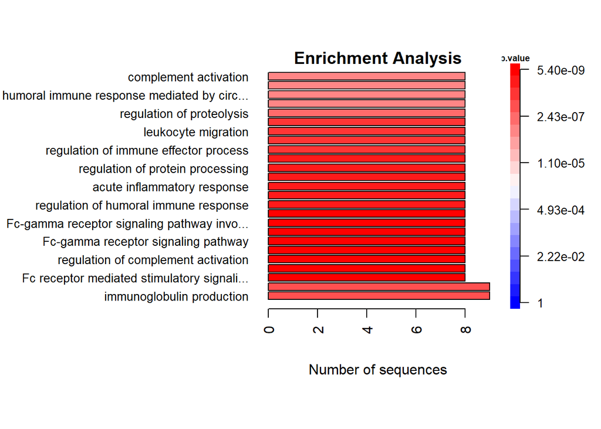

```r
# Plots
plotEnrich = function(allRes, title){
  # Plotting!
  layout(t(1:2), widths = c(8,1))
  par(mar=c(4, .5, .7, .7), oma = c(3, 15, 3, 4), las = 1)

  rbPal = colorRampPalette(c('red', 'white', 'blue'))
  pvalue = as.numeric(gsub("<", "", allRes$classicFisher))
  max_value = as.integer(max(-log(pvalue))) + 1
  pv_range = exp(-seq(max_value, 0, -1))
  allRes$Color = rbPal(max_value) [cut(pvalue, pv_range)]

  o = order(allRes$Significant, decreasing = T)
  barplot(allRes$Significant[o], names.arg = allRes$Term[o], las = 2, horiz = T, col = allRes$Color[o],
          xlab = "Number of sequences", main = title, cex.names = 0.85)

  image(0, seq(1, max_value), t(seq_along(seq(1, max_value))), col = rev(rbPal(max_value)), axes = F, ann = F)
  pv_label = exp(-seq(log(1), -log(min(pvalue)), l = 6))
  pv_label = formatC(pv_label, format = "e", digits = 2)
  axis(4, at = seq(1, max_value, length = 6), labels = c(1, pv_label[2:6]), cex.axis = 0.85)
  title("p.value", cex.main = 0.6)
}

plotEnrich(allRes = allRes, title = 'Enrichment Analysis')
```